# Test 2, STAT 245 for scr24

Author

STAT 245 Fall 2023

## Response variable

Fit a regression model using as your response variable: number of bird species present.

## Data Access

You can find your data at: https://sldr.netlify.app/data/island-birds.csv

## Context

This dataset was recently analyzed by Yuhao Zhao and colleagues in the paper [*Land-use change interacts with island biogeography to alter bird community assembly*](https://royalsocietypublishing.org/doi/10.1098/rspb.2023.2245#d1e1679).

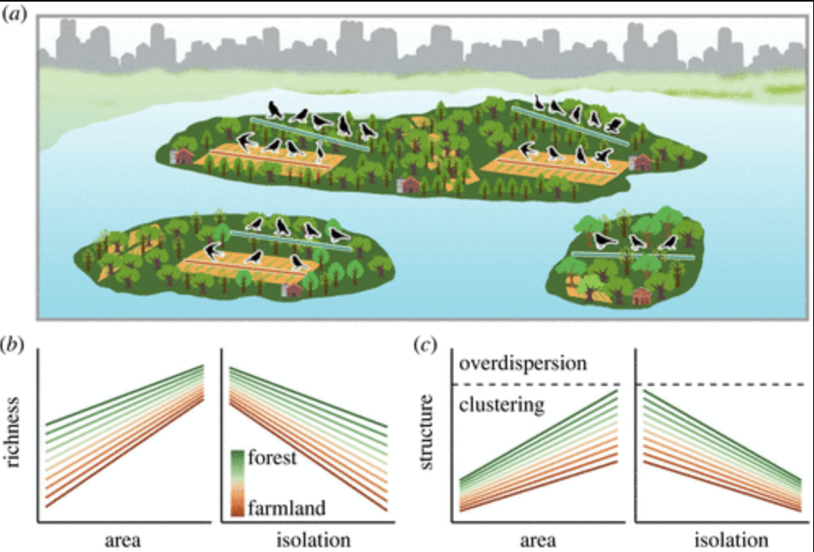

What the researchers expected their study might find. Image from Zhao et al. 2024.

The researchers state,

> > [Human] activities have reshaped biodiversity on islands worldwide. However, it remains unclear how island attributes and land-use change interactively shape … island biodiversity … To answer this, we conducted bird surveys in various land-use types (mainly forest and farmland) using transects on 34 oceanic land-bridge islands in the largest archipelago of China. We found that bird species richness increased with island area and decreased with isolation, regardless of the intensity of land-use change. However, forest-dominated habitats exhibited lower richness than farmland-dominated habitats. Island bird assemblages generally comprised species that share more similar traits … than expected … Contrary to our expectations, we observed that bird assemblages in forest-dominated habitats were more clustered on large and close islands, whereas assemblages in farmland-dominated habitats were more clustered on small islands. Our findings … suggest that agricultural landscapes on large islands may play essential roles in protecting countryside island biodiversity.

Can you replicate some of the study’s findings with your analysis?

Variables in the dataset include:

- Location variables, `transect_ID` and `island_ID`. Each transect is within one island.
- `species_richness`: the number of distinct bird species that were found on this transect
- `island_area` in log$_{10}$(hectares). Measure of island size.
- `isolation`, kilometers from nearest other island
- `func_dist`: a relative measure of how similar the bird species present are, based on features of the birds such as body length, body mass, bill length, wing length, tail length, and others
- `phyl_dist`: a relative measure of how similar the bird species present are, based on their evolutionary relatedness
- `mean_HWI`: the mean hand-wing index of the bird species present. This index measures the bird’s ability to disperse (flying potential to reach a new, maybe far away habitat).
- `farmland_cover`, `forest_cover`, and `settlement_cover` measure land use. They give the proportion of the transect that is farmland, forest, and human settlements.
- `main_land_use` tells whether a greater proportion of the land use is for “farm” or “forest”.